# Airplane-wildlife Strikes Analysis

Author: Pongsatorn Konggate

# Introduction

This is a project for Google Data Analytics course by Coursera. Which will mostly use the steps of the data analysis process: ask, prepare, process, analyze, share, act for this analysis. Topic of analysis will focus on airplane and wildlifes collision which can cause damage to airplane and in some case cause injuries to passenger or worse, fatalities.

## Task to investigate

- **Trend of airplane and wildlifes collision and how to reduce incidents.**

## Data

- **Data Source**: This dataset is from kaggle’s [Aircraft Wildlife Strikes, 1990-2015](https://www.kaggle.com/datasets/faa/wildlife-strikes) under [CC0 license](https://creativecommons.org/publicdomain/zero/1.0/). With the original data source from [FAA Wildlife Stirke Database](https://wildlife.faa.gov/home) which contains records of voluntary reported wildlife strikes in United States.

## Data cleaning, manipulation and analysis

- We are using SQL to preprocess data in this following steps
- Looking at Schema to learn about data type and detail of data of each fields to familiarize with data.
- Sorting and filtering for interested data into seperate table.

```r
library(tidyverse)
library(reshape)
library(RColorBrewer)
library(plyr)
```

```r
df_database <- data.frame(read_csv("database.csv"))
```

```r
dim(df_database)
```

```
## [1] 174104     66
```

```r
length(unique(df_database[["Record.ID"]]))
```

```
## [1] 174104
```

Length of unique record id is equal to length of database so there are no duplicate record.

```r
summary(df_database)
```

```
##    Record.ID      Incident.Year  Incident.Month    Incident.Day
##  Min.   :  1000   Min.   :1990   Min.   : 1.000   Min.   : 1.00
##  1st Qu.:205412   1st Qu.:2001   1st Qu.: 5.000   1st Qu.: 8.00
##  Median :249103   Median :2007   Median : 8.000   Median :16.00
##  Mean   :241204   Mean   :2006   Mean   : 7.172   Mean   :15.71
##  3rd Qu.:322592   3rd Qu.:2012   3rd Qu.: 9.000   3rd Qu.:23.00
##  Max.   :367445   Max.   :2015   Max.   :12.000   Max.   :31.00
##
##  Operator.ID          Operator           Aircraft         Aircraft.Type
##  Length:174104      Length:174104      Length:174104      Length:174104
##  Class :character   Class :character   Class :character   Class :character
##  Mode  :character   Mode  :character   Mode  :character   Mode  :character
##
##
##
##
##  Aircraft.Make      Aircraft.Model   Aircraft.Mass    Engine.Make
##  Length:174104      Min.   :  0.00   Min.   :1.00    Min.   : 1.00
##  Class :character   1st Qu.: 10.00   1st Qu.:3.00    1st Qu.:10.00
##  Mode  :character   Median : 22.00   Median :4.00    Median :22.00
##                     Mean   : 24.79   Mean   :3.51    Mean   :21.31
##                     3rd Qu.: 37.00   3rd Qu.:4.00    3rd Qu.:34.00
##                     Max.   :451.00   Max.   :5.00    Max.   :92.00
##                     NA's   :51668    NA's   :46784   NA's   :50670
##   Engine.Model      Engines      Engine.Type        Engine1.Position
##  Min.   : 0.0    Min.   :1.00    Length:174104      Min.   :1.00
##  1st Qu.: 1.0    1st Qu.:2.00    Class :character   1st Qu.:1.00
##  Median : 4.0    Median :2.00    Mode  :character   Median :1.00
##  Mean   : 9.9    Mean   :2.06                       Mean   :2.98
##  3rd Qu.:10.0    3rd Qu.:2.00                       3rd Qu.:5.00
##  Max.   :97.0    Max.   :4.00                       Max.   :7.00
##  NA's   :52142   NA's   :46762                      NA's   :47921
##  Engine2.Position Engine3.Position Engine4.Position  Airport.ID
##  Min.   :1.00     Min.   :1.0      Min.   :1.00     Length:174104
##  1st Qu.:1.00     1st Qu.:1.0      1st Qu.:1.00     Class :character
##  Median :1.00     Median :4.0      Median :1.00     Mode  :character
##  Mean   :2.92     Mean   :3.1      Mean   :2.06
##  3rd Qu.:5.00     3rd Qu.:5.0      3rd Qu.:4.00
##  Max.   :7.00     Max.   :5.0      Max.   :5.00
##  NA's   :55389    NA's   :162500   NA's   :171012
```

[output cut: 81 more lines]

```
##  Min.   :0.00000   Min.   :0.000000   Min.   :0.000000   Min.   :0.000000
##  1st Qu.:0.00000   1st Qu.:0.000000   1st Qu.:0.000000   1st Qu.:0.000000
##  Median :0.00000   Median :0.000000   Median :0.000000   Median :0.000000
##  Mean   :0.01123   Mean   :0.004176   Mean   :0.005962   Mean   :0.004216
##  3rd Qu.:0.00000   3rd Qu.:0.000000   3rd Qu.:0.000000   3rd Qu.:0.000000
##  Max.   :1.00000   Max.   :1.000000   Max.   :1.000000   Max.   :1.000000
##
##   Other.Strike      Other.Damage
##  Min.   :0.00000   Min.   :0.000000
##  1st Qu.:0.00000   1st Qu.:0.000000
##  Median :0.00000   Median :0.000000
##  Mean   :0.09073   Mean   :0.008989
##  3rd Qu.:0.00000   3rd Qu.:0.000000
##  Max.   :1.00000   Max.   :1.000000
##
```

```r
colSums(is.na(df_database))
```

```
##            Record.ID        Incident.Year       Incident.Month
##                    0                    0                    0
##         Incident.Day          Operator.ID             Operator
##                    0                    0                    0
##             Aircraft        Aircraft.Type        Aircraft.Make
##                    0                41030                43053
##       Aircraft.Model        Aircraft.Mass          Engine.Make
##                51668                46784                50670
##         Engine.Model              Engines          Engine.Type
##                52142                46762                46822
##     Engine1.Position     Engine2.Position     Engine3.Position
##                47921                55389               162500
##     Engine4.Position           Airport.ID              Airport
##               171012                    0                  290
##                State           FAA.Region       Warning.Issued
##                21976                18902                97686
##         Flight.Phase           Visibility        Precipitation
##                55302                64171                85782
##               Height                Speed             Distance
##                70427               102846                74391
##           Species.ID         Species.Name     Species.Quantity
##                    0                   80                 4477
##        Flight.Impact           Fatalities             Injuries
##                74639               173539               173875
##      Aircraft.Damage        Radome.Strike        Radome.Damage
##                    0                    0                    0
##    Windshield.Strike    Windshield.Damage          Nose.Strike
##                    0                    0                    0
##          Nose.Damage       Engine1.Strike       Engine1.Damage
##                    0                    0                    0
##       Engine2.Strike       Engine2.Damage       Engine3.Strike
##                    0                    0                    0
##       Engine3.Damage       Engine4.Strike       Engine4.Damage
##                    0                    0                    0
##      Engine.Ingested     Propeller.Strike     Propeller.Damage
##                    0                    0                    0
## Wing.or.Rotor.Strike Wing.or.Rotor.Damage      Fuselage.Strike
##                    0                    0                    0
##      Fuselage.Damage  Landing.Gear.Strike  Landing.Gear.Damage
##                    0                    0                    0
##          Tail.Strike          Tail.Damage        Lights.Strike
##                    0                    0                    0
##        Lights.Damage         Other.Strike         Other.Damage
##                    0                    0                    0
```

There are many missing value but we can’t just delete row with null value because another column in that row contain valuable information we will deal with it case by case.

Next we will look at species of wildlife that cause incident most often and most damage.

```sql
SELECT Incident_Year, count(Incident_Year) as Count
FROM `aircraft-wildlife-strikes.aw_strikes.aircraft wildlife strikes`
where Aircraft_Type = 'A'
group by Incident_Year
order by Incident_Year
```

Use aggregation function Count() to count number of incident occur each year (Incident_Year don’t have null value)  
We will focus on airplane by filtering use Aircraft_Type=‘A’.

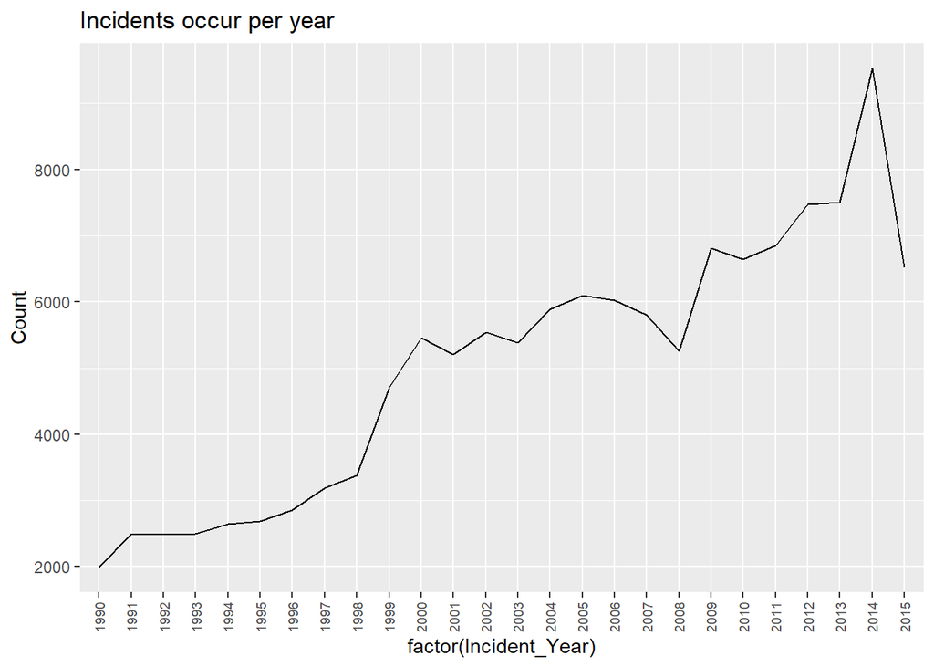

```r
df_incidents_year <- data.frame(read_csv("Incidents_per_year.csv", show_col_types = FALSE))

ggplot(data=df_incidents_year, aes(x=factor(Incident_Year), y=Count, group=1)) +
  geom_line() +  scale_fill_brewer(palette = "Blues") +
  labs(title="Incidents occur per year") +
  theme(axis.text.x = element_text(angle=90, vjust=0.5, hjust=1, size=7))
```

- Insight

  Incident increasing by year that may come from increase in number of flights, increase in populations of the wildlifes in the nearby area.

Next we will look at species that cause most incidents.

```sql
SELECT Species_Name,
       count(*) Count,
       sum(Radome_Damage) Radome_Damage,      ---sum of damage group by species
       sum(Windshield_Damage) Windshield_Damage,
       sum(Nose_Damage) Nose_Damage,
       sum(Engine1_Damage) Engine1_Damage,
       sum(Engine2_Damage) Engine2_Damage,
       sum(Engine3_Damage) Engine3_Damage,
       sum(Engine4_Damage) Engine4_Damage,
       sum(Propeller_Damage) Propeller_Damage,
       sum(Wing_or_Rotor_Damage) Wing_or_Rotor_Damage,
       sum(Fuselage_Damage) Fuselage_Damage,
       sum(Landing_Gear_Damage) Landing_Gear_Damage,
       sum(Tail_Damage) Tail_Damage,
       sum(Lights_Damage) Lights_Damage,
       sum(Other_Damage) Other_Damage
FROM `aircraft-wildlife-strikes.aw_strikes.aircraft wildlife strikes`
WHERE Aircraft_Type = 'A'
GROUP BY Species_Name
ORDER BY Count DESC
```

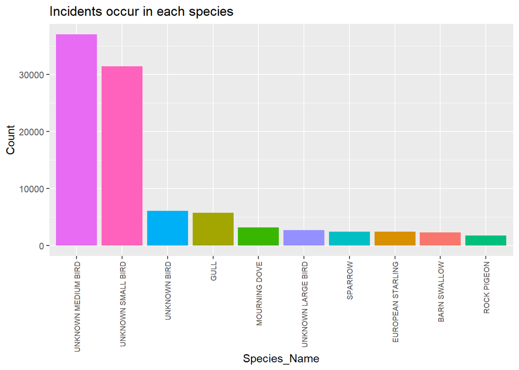

```r
df_species_dmg <- data.frame(read_csv("Species_damage.csv", show_col_types = FALSE))

ggplot(data=df_species_dmg[1:10,],
       aes(x=forcats::fct_reorder(Species_Name, desc(Count)),
           y=Count, fill=Species_Name)) +
  geom_col() +
  labs(x="Species_Name", title="Incidents occur in each species") +
  theme(axis.text.x=element_text(angle=90, vjust=0.5, hjust=1, size=7),
        legend.position="none")
```

- Insight

  Most incidents are cause by unknown birds (some of its is send to identify), and most incident that cuase by identifiable birds is gull. Large birds incident is significant lower because it is easier to spot and low in population compare to small and medium birds, and small, medium birds tend to stay as group which has much more chance to cause incidents.

When it come to birds maybe the migration of birds also affect in frequency of incidents let see incedents by month.

```sql
SELECT Incident_Month, count(Incident_Month) as Count
FROM `aircraft-wildlife-strikes.aw_strikes.aircraft wildlife strikes`
where Aircraft_Type = 'A'
group by Incident_Month
order by Incident_Month
```

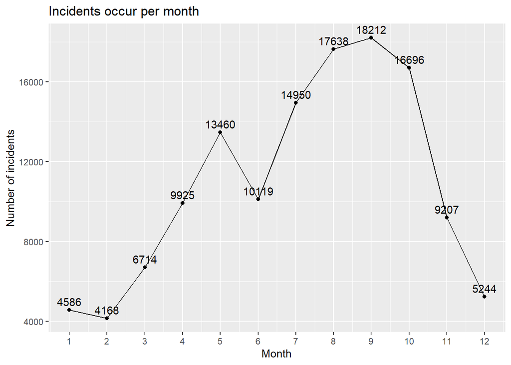

```r
df_incident_m <- data.frame(read_csv("Incident_month.csv", show_col_types = FALSE))
ggplot(data=df_incident_m, aes(x=Incident_Month, y=Count)) +
  geom_line() + geom_point() +
  geom_text(aes(label=Count), vjust=-0.5) +
  labs(x="Month", y="Number of incidents", title="Incidents occur per month") +
  scale_x_continuous(n.breaks=12)
```

- Insight

```
Incidents occur by month is significant higher at May to October with the peak at 18212 incidents in September, incidents occur much lower in December to February (winter Season).Since each bird species migrating at a different period of time further investigation is needed in order to see pattern in the individual bird species.
Let compare incidents by top 5 known species.
```

```sql
SELECT Incident_Month, Species_Name, Count
FROM
  (
  SELECT  aws.Incident_Month, aws.Species_Name, Count(*) as Count,
          aws_dmg.Count as Dmg,
          DENSE_RANK() OVER(ORDER BY aws_dmg.Count DESC) AS Dmg_Rank --> Ranking specie dmg
  FROM `aircraft-wildlife-strikes.aw_strikes.aircraft wildlife strikes` as aws
    INNER JOIN `aircraft-wildlife-strikes.aw_strikes.aws_dmg` as aws_dmg --> previous table
    ON aws.Species_Name = aws_dmg.Species_Name
  WHERE aws.Species_Name IS NOT NULL
        AND aws.Species_Name NOT LIKE '%UNKNOWN%'   --> Filter out unknown bird
        AND aws.Aircraft_Type = 'A'
  GROUP BY aws.Incident_Month, aws.Species_Name, Dmg
  ORDER BY Dmg DESC
  )
WHERE Dmg_Rank < 6
ORDER BY Dmg_Rank ASC
```

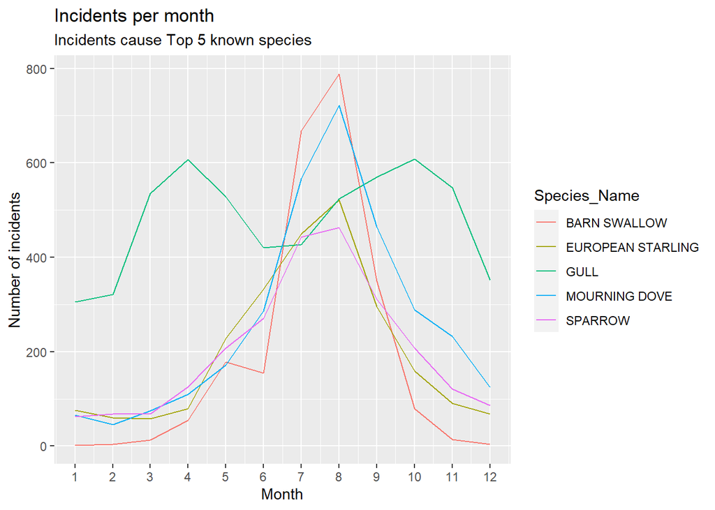

```r
df_top_dmg <- data.frame(read_csv("top5_dmg_month.csv", show_col_types = FALSE))

ggplot(data=df_top_dmg, aes(x=Incident_Month, y=Count, color=Species_Name)) +
  geom_line() +
  #geom_text(aes(label=Count), vjust=-0.5, size=3) +
  labs(x="Month",y="Number of incidents", title="Incidents per month",
       subtitle="Incidents cause Top 5 known species") +
  scale_x_continuous(n.breaks=12)
```

Incidents by Gull is peak around 600 incidents in April and October while incidents by other species is rising during summer with it peak at August and incidents are dropping when enter autumn, which support migration hypothesis.

Next let see percentage of damage that cause by each species

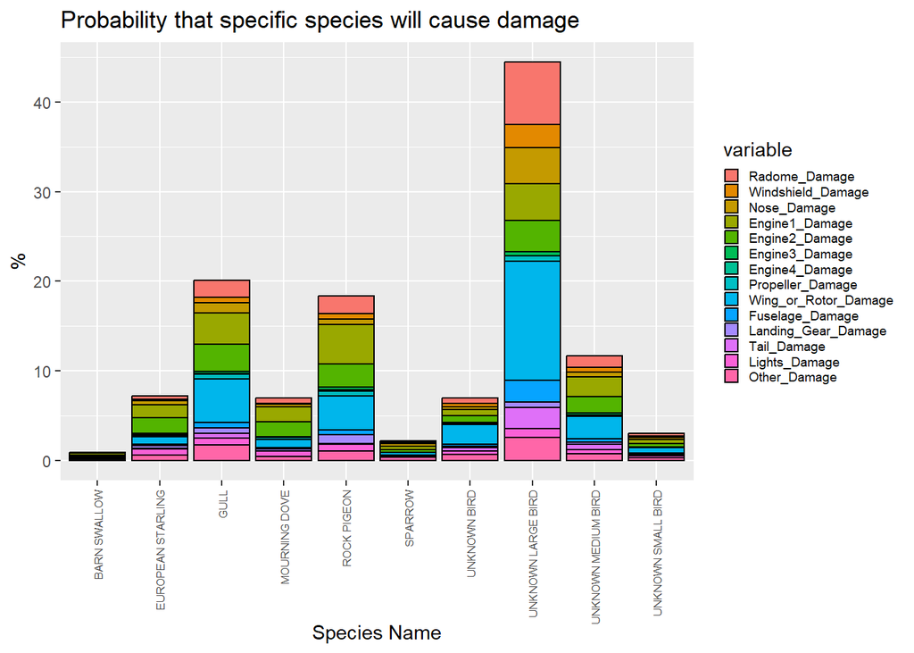

```r
df1 <- data.frame(df_species_dmg)
df2 <- df1[,3:16]/df1[,2]*100      # Calculate into percentage.
df1[,3:16] <- df2
df1[2] <- NULL                     # Drop count column
df3 <- melt(df1[1:10, ], id.vars="Species_Name", variable.names="Damage_parts")
#change dataframe from wide to long using melt fuction

ggplot(data=df3, aes(x=Species_Name, y=value, fill=variable)) +
  geom_col(color="black") +
  labs(x="Species Name",y="%",
       title="Probability that specific species will cause damage") +
  theme(axis.text.x=element_text(angle=90, vjust=0.5, hjust=1, size=6),
        legend.text=element_text(size=7), legend.key.size = unit(0.3, "cm"))
```

We calculate percentage of damage in each part (damage part/number of incident) by slicing dataframe and calculate Then we change dataframe from wide to long using melt function to make it easier to plot.

- Insight

  At the glance we can see that most damage come from large birds at 45% and overall damage occur at wing/rotor, Engine1, Engine2 with radome damage by large bird is much higher compare to other type of birds. In order to reduce damage we must focus on detection of medium to large birds.

Next let look at incidents occur at each flight phase.

```sql
SELECT Flight_Phase,
       CAST(AVG(Height) AS INT) AS Height,
       CAST(AVG(Speed) AS INT) AS Speed,
       count(*) AS Count_Incident
FROM `aircraft-wildlife-strikes.aw_strikes.aircraft wildlife strikes`
WHERE Aircraft_Type = 'A' and Flight_Phase is not null  ---filter null in flight phase out
GROUP BY Flight_Phase
ORDER BY Count_Incident DESC
```

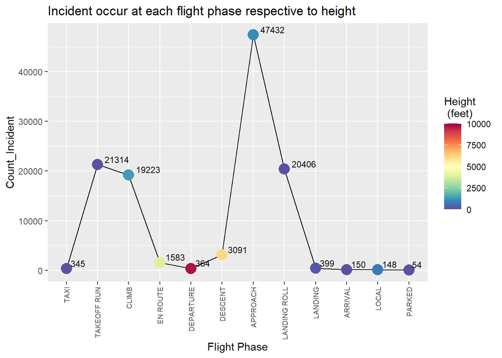

```r
df_flight_p <- data.frame(read_csv("Phase_Height.csv", show_col_types = FALSE))
df_flight_p <- cbind(Index=c(7, 2, 8, 3, 6, 4, 9, 5, 1, 10, 11,  12),df_flight_p)
#Add index column for easier to rearrange flight phase
Palette <- colorRampPalette(rev(brewer.pal(11, "Spectral")))

#plot incident relative to height(feet above ground level)
ggplot(data=df_flight_p, aes(forcats::fct_reorder(Flight_Phase, Index),
                             y=Count_Incident, group=1)) +
  geom_line() + geom_point(aes(color=Height), size=5) +
  theme(axis.text.x=element_text(angle=90, vjust=0.5, hjust=1, size=7)) +
  scale_colour_gradientn(colours = Palette(100), limits=c(0, 10000)) +
  labs(x="Flight Phase", color="Height\n (feet)",
       title="Incident occur at each flight phase respective to height") +
  geom_text(aes(label=Count_Incident), vjust=-0.3, hjust=-0.3 , size=3)
```

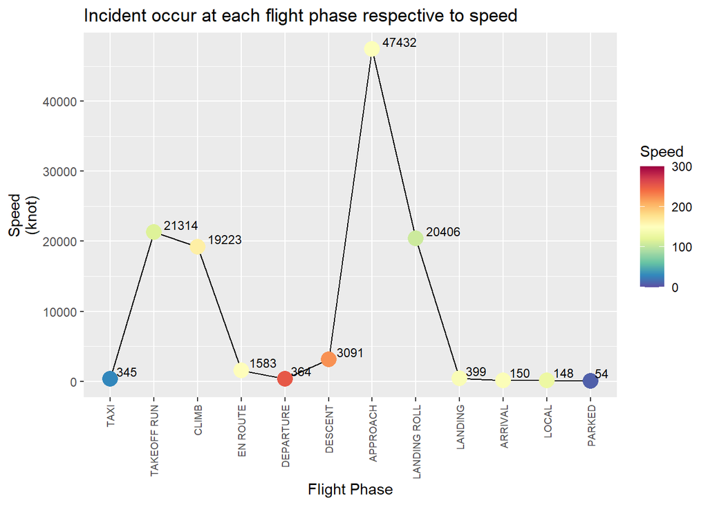

```r
#plot incident relative to speed(knot)
ggplot(data=df_flight_p, aes(forcats::fct_reorder(Flight_Phase, Index),
                             y=Count_Incident, group=1)) +
  geom_line() + geom_point(aes(color=Speed), size=5) +
  theme(axis.text.x=element_text(angle=90, vjust=0.5, hjust=1, size=7)) +
  scale_colour_gradientn(colours = Palette(100), limits=c(0, 300)) +
  labs(x="Flight Phase" ,y="Speed\n(knot)",
       title="Incident occur at each flight phase respective to speed") +
  geom_text(aes(label=Count_Incident), vjust=-0.3, hjust=-0.3 , size=3)
```

We add number index into dataframe and use it as reference in order to rearrange plot.

Let compare data distribution of height from ‘Climb’ to ‘Approach’ phase.

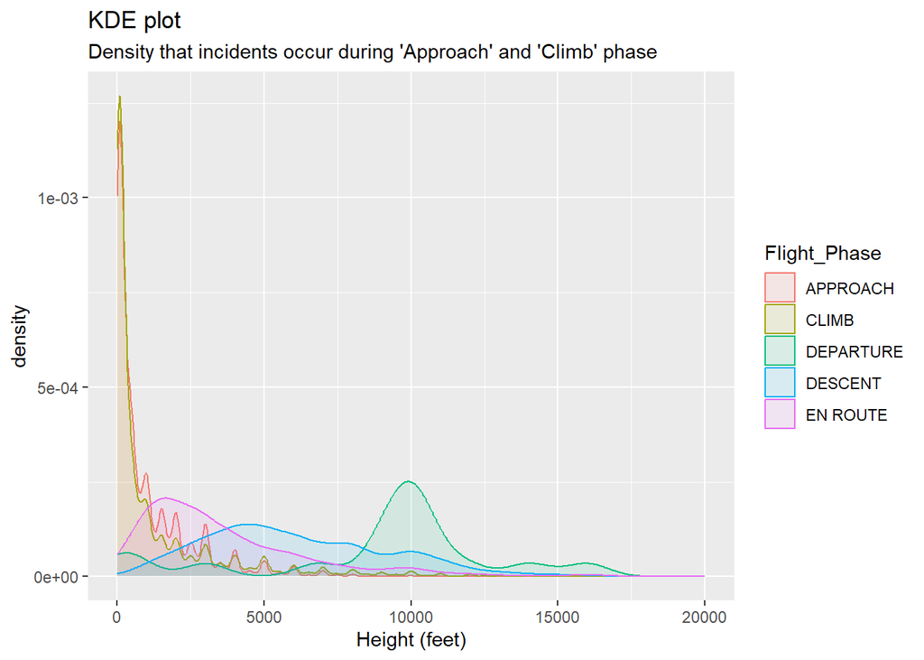

```r
df_ca <- data.frame(read_csv("FPH.csv", show_col_types = FALSE))

ggplot(data=df_ca,
       aes(x=Height, color=Flight_Phase, fill=Flight_Phase)) +
  geom_density(alpha=0.1) +
  xlim(-2,20000) +
  labs(x="Height (feet)" ,
       title="KDE plot",
       subtitle="Density that incidents occur during 'Approach' and 'Climb' phase")
```

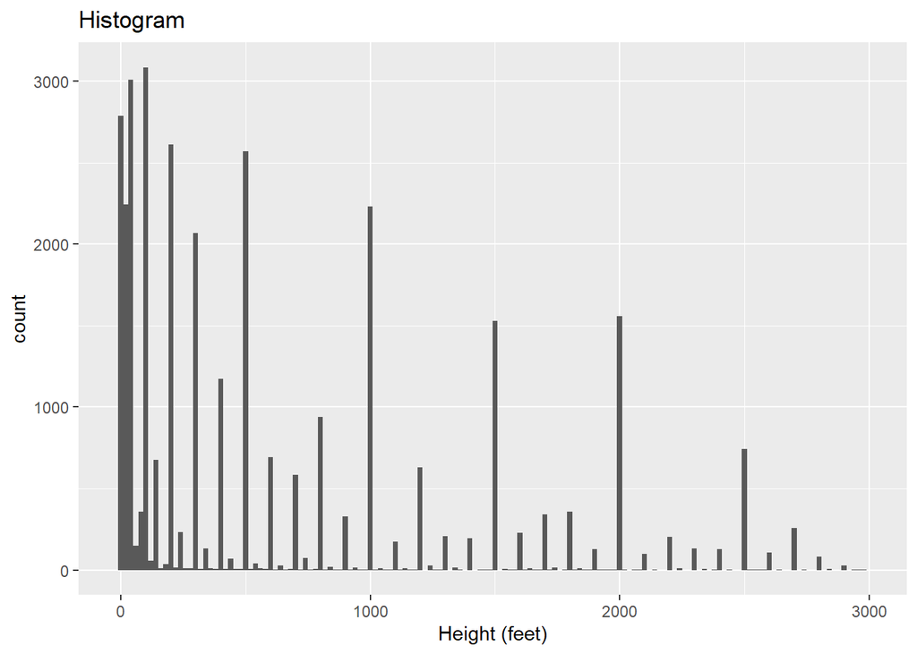

```r
ggplot(data=df_ca,aes(x=Height)) +
  geom_histogram(data=subset(df_ca, Flight_Phase==("APPROACH")), binwidth=20) +
  xlim(-20,3000) +
  labs(x="Height (feet)", title="Histogram")
```

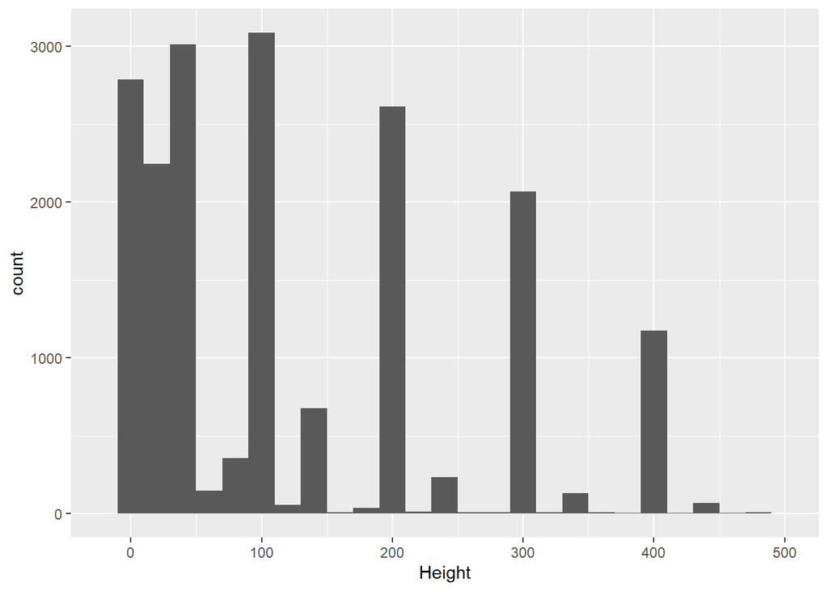

```r
ggplot(data=df_ca,aes(x=Height)) +
  geom_histogram(data=subset(df_ca, Flight_Phase==("APPROACH")), binwidth=20) +
  xlim(-20,500)
```

- Insight

  Most incidents occur at low attitude around 0-1500 feet, while the incidents occur significant lower at higher attitude. What is interesting is incident occur at ‘Approach’ phase is twice as much compare to ‘Climb’ phase which occur at almost the same height/speed. Maybe from bird’s perspective it can notice airplane sooner when airplane still in ‘Take-off run’ phase (higher airplane sound and visibility at low attitude but lower sound and visibility at higher attitude) Data of approach and climb phase are skewd.

  We can see from histogram plot that data around 0-100 feet is oddly high, because the dataset is voluntary report and it didn’t define height of each phase, that mean some of incidents occur at 0 feet may reported as ‘Approach’ instead of ‘Landing’. Still, the fact that most incidents occur at low attitude still hold true.

We can manipulate data by define height of each phase and change Flight_Phase according to defined height but it does not seem to get us more information in this analysis.

Next let see distance between airport and location that incidents occur.

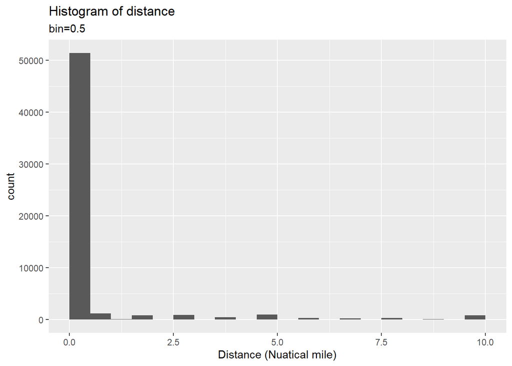

```r
df_dt <- data.frame(read_csv("Distance.csv", show_col_types = FALSE))

ggplot(data=df_dt,
      aes(x=Distance)) +
  geom_histogram(binwidth=0.5, boundary=0) +
  xlim(0,10) +
  labs(x="Distance (Nuatical mile)" ,
      title="Histogram of distance",
      subtitle="bin=0.5")
```

Most incidents happen around airport.

# Key finding

- Most incident come from small and medium birds.
- Most damage come from large birds follow by medium birds.
- Incidents occur in December to February is significant lower from the rest of the year.
  - Each bird has different migration period, further exploration is needed in order to understand population of specific bird around airplane travel path during each season.
- Most incident occur during ‘Approach’ phase follow by ‘Take off run’, ‘Landing roll’ and ‘climb phase’.
  - Incident occur upon arrival is significant higher compare to departure ,further exploration about ‘Approach’ phase such as vision from airplane and bird perspective in order to reduce incident in this phase.

# Conclusion

- Since most of incidents occur around airport area, habitat management around airport might be an effective strategy to control population of wildlife around airport area. Bird migration further exploration should be conduct in order to handle each habitat of individual species effectively for each season.